# MachineLearning_Lab1_Natasha_Nika

Natasha Savic, Nika Tamaio Flores

17/02/2018

# Introduction

If we were to ask a home buyer to explain their dream house, they would probably not begin with the height of the garage ceiling or the proximity to a highway. The questions that really concern home buyers are which the determinants of housing prices are. Would it be possible to explain the price of a house by considering only some particular features like e.g. the neighbourhood of the house?

Good, there are aspiring data scientists like us to solve such questions and, even better, provide a model that predicts housing prices!

So brace yourself, pour a big glass of beer and enjoy our predictive analysis of housing prices in Ames!

## Libraries

```r
library(arm)
library(ggplot2)
library(plyr)
library(dplyr)
library(moments)
library(glmnet)
library(caret)
library(e1071)
library(tidyr)
library(mice)
library(MASS)
library(tree)
library(gbm)
library(VIM)
```

## Data Reading

In this part, we will clean and read the data.

```r
setwd('/Users/natasha/Desktop/ML II/Lab_1_Natasha_Nika')
df <- read.csv('train.csv', sep=',', header=T)
```

## Check NA’s

```r
na.cols <- which(colSums(is.na(df)) > 0)
paste('There are', length(na.cols), 'columns with missing values')
```

```
## [1] "There are 19 columns with missing values"
```

```r
sort(colSums(sapply(df[na.cols], is.na)), decreasing = TRUE)
```

```
##       PoolQC  MiscFeature        Alley        Fence  FireplaceQu
##         1453         1406         1369         1179          690
##  LotFrontage   GarageType  GarageYrBlt GarageFinish   GarageQual
##          259           81           81           81           81
##   GarageCond BsmtExposure BsmtFinType2     BsmtQual     BsmtCond
##           81           38           38           37           37
## BsmtFinType1   MasVnrType   MasVnrArea   Electrical
##           37            8            8            1
```

# Data Preparation

## Data Cleaning - Train Dataset

The visualisation part of this section has been adopted by [missingDataLab](http://web.maths.unsw.edu.au/~dwarton/missingDataLab.html).

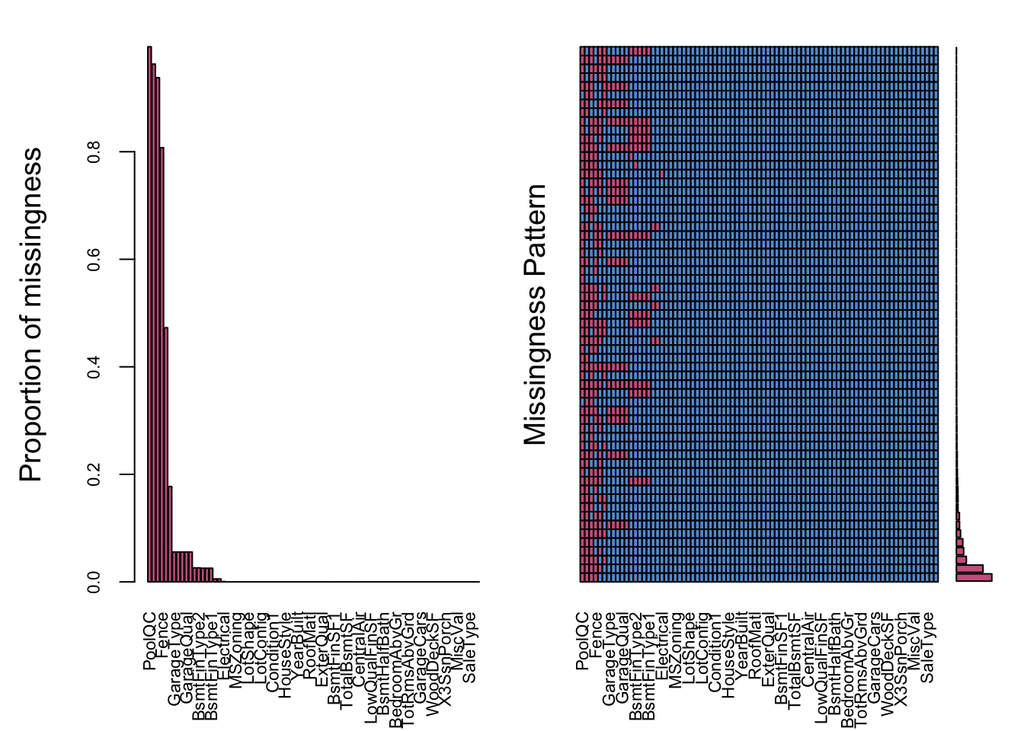

```
##
##  Variables sorted by number of missings:
##       Variable        Count
##         PoolQC 0.9952054795
##    MiscFeature 0.9630136986
##          Alley 0.9376712329
##          Fence 0.8075342466
##    FireplaceQu 0.4726027397
##    LotFrontage 0.1773972603
##     GarageType 0.0554794521
##    GarageYrBlt 0.0554794521
##   GarageFinish 0.0554794521
##     GarageQual 0.0554794521
##     GarageCond 0.0554794521
##   BsmtExposure 0.0260273973
##   BsmtFinType2 0.0260273973
##       BsmtQual 0.0253424658
##       BsmtCond 0.0253424658
##   BsmtFinType1 0.0253424658
##     MasVnrType 0.0054794521
##     MasVnrArea 0.0054794521
##     Electrical 0.0006849315
##             Id 0.0000000000
##     MSSubClass 0.0000000000
##       MSZoning 0.0000000000
##        LotArea 0.0000000000
##         Street 0.0000000000
##       LotShape 0.0000000000
##    LandContour 0.0000000000
##      Utilities 0.0000000000
##      LotConfig 0.0000000000
##      LandSlope 0.0000000000
##   Neighborhood 0.0000000000
##     Condition1 0.0000000000
##     Condition2 0.0000000000
##       BldgType 0.0000000000
##     HouseStyle 0.0000000000
##    OverallQual 0.0000000000
##    OverallCond 0.0000000000
##      YearBuilt 0.0000000000
```

[output cut: 29 more lines]

```
##     GarageCars 0.0000000000
##     GarageArea 0.0000000000
##     PavedDrive 0.0000000000
##     WoodDeckSF 0.0000000000
##    OpenPorchSF 0.0000000000
##  EnclosedPorch 0.0000000000
##     X3SsnPorch 0.0000000000
##    ScreenPorch 0.0000000000
##       PoolArea 0.0000000000
##        MiscVal 0.0000000000
##         MoSold 0.0000000000
##         YrSold 0.0000000000
##       SaleType 0.0000000000
##  SaleCondition 0.0000000000
##      SalePrice 0.0000000000
```

```r
#Check Missing Values
#Now we will check the proportion of missing values plotting them
df_aggr = aggr(df, col=mdc(1:2), numbers=TRUE, sortVars=TRUE, labels=names(df), cex.axis=.7, gap=3, ylab=c("Proportion of missingness","Missingness Pattern"))
```

Sweet! Now we see that there are particular features we need to focus on when cleaning the data. As the plot illustrates, critical features include PoolQC, MiscFeature, Alley, Fence and FireplaceQu and convert features to the right data type.

```r
#take care of critical Columns manually, rest using mice
df$Alley = factor(df$Alley, levels=c(levels(df$Alley), "None")) #appending another level "None" to exisiting levels
df$Alley[is.na(df$Alley)] = "None" #replace NA's by "None"

# Fence : NA means "no fence"
df$Fence = factor(df$Fence, levels=c(levels(df$Fence), "No"))
df$Fence[is.na(df$Fence)] = "No"

# FireplaceQu : NA means "no fireplace"
df$FireplaceQu = factor(df$FireplaceQu, levels=c(levels(df$FireplaceQu), "No")) #factor the data
df$FireplaceQu[is.na(df$FireplaceQu)] = "No"

# MiscFeature : NA = "no misc feature"
df$MiscFeature = factor(df$MiscFeature, levels=c(levels(df$MiscFeature), "No"))
df$MiscFeature[is.na(df$MiscFeature)] = "No"

# PoolQC : data description says NA means "no pool"
df$PoolQC = factor(df$PoolQC, levels=c(levels(df$PoolQC), "No"))
df$PoolQC[is.na(df$PoolQC)] = "No"


#Factorize features. Some numerical features are actually really categories
df$MSSubClass <- as.factor(df$MSSubClass)
df$MoSold <- as.factor(df$MoSold)
```

## Data Imputation

Cool, that wasn’t even that painful! We will now proceed with removing those missing values and make another plot to cross-validate. For this, we will use the package mice. The Function mice() is a Markov Chain Monte Carlo (MCMC) method that uses the correlation structure of the data and imputes missing values for each incomplete variable’ times by regression of incomplete variables on the other variables iteratively. However, we will not apply ‘mice’ on every feature but rather “clean” critical features manually and perform imputations for the remaining features using the quickpred() function to leverage computational time with accuracy.

```r
imp = mice(df, pred=quickpred(df, minpuc = 0.25, exclude = c("PoolQC", "MiscFeature", "Alley", "Fence", "FireplaceQu", "LotFrontage", "SalePrice")), maxit = 1, method = 'cart')
summary(imp)
completedData <- complete(imp,1)
```

To doublecheck the “cleaniliness” of our data we will plot it once more.

```r
df_aggr = aggr(completedData, col=mdc(1:2), numbers=TRUE, sortVars=TRUE, labels=names(completedData), cex.axis=.7, gap=3, ylab=c("Proportion of missingness","Missingness Pattern"))
```

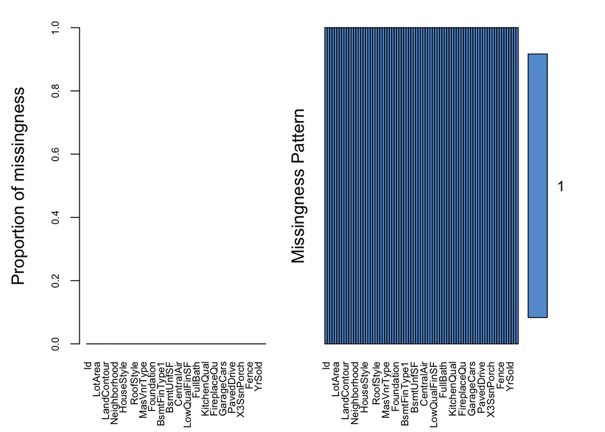

```
##
##  Variables sorted by number of missings:
##       Variable Count
##             Id     0
##     MSSubClass     0
##       MSZoning     0
##    LotFrontage     0
##        LotArea     0
##         Street     0
##          Alley     0
##       LotShape     0
##    LandContour     0
##      Utilities     0
##      LotConfig     0
##      LandSlope     0
##   Neighborhood     0
##     Condition1     0
##     Condition2     0
##       BldgType     0
##     HouseStyle     0
##    OverallQual     0
##    OverallCond     0
##      YearBuilt     0
##   YearRemodAdd     0
##      RoofStyle     0
##       RoofMatl     0
##    Exterior1st     0
##    Exterior2nd     0
##     MasVnrType     0
##     MasVnrArea     0
##      ExterQual     0
##      ExterCond     0
##     Foundation     0
##       BsmtQual     0
##       BsmtCond     0
##   BsmtExposure     0
##   BsmtFinType1     0
##     BsmtFinSF1     0
##   BsmtFinType2     0
##     BsmtFinSF2     0
```

[output cut: 29 more lines]

```
##     WoodDeckSF     0
##    OpenPorchSF     0
##  EnclosedPorch     0
##     X3SsnPorch     0
##    ScreenPorch     0
##       PoolArea     0
##         PoolQC     0
##          Fence     0
##    MiscFeature     0
##        MiscVal     0
##         MoSold     0
##         YrSold     0
##       SaleType     0
##  SaleCondition     0
##      SalePrice     0
```

The output shows that there are no missing values for our data anymore. Let’s now repeat the same for our test dataset!

## Data Cleaning Test Dataset

We will do now the same for the test dataset to ensure consistency. We will name the test dataset as *dft* whereas the training dataset represents *df*.

```r
dft <- read.csv('test.csv', sep=',', header=T)
```

### Check NA’s

```r
na.cols <- which(colSums(is.na(dft)) > 0)
paste('There are', length(na.cols), 'columns with missing values')
```

```
## [1] "There are 33 columns with missing values"
```

```r
sort(colSums(sapply(dft[na.cols], is.na)), decreasing = TRUE)
```

```
##       PoolQC  MiscFeature        Alley        Fence  FireplaceQu
##         1456         1408         1352         1169          730
##  LotFrontage  GarageYrBlt GarageFinish   GarageQual   GarageCond
##          227           78           78           78           78
##   GarageType     BsmtCond     BsmtQual BsmtExposure BsmtFinType1
##           76           45           44           44           42
## BsmtFinType2   MasVnrType   MasVnrArea     MSZoning    Utilities
##           42           16           15            4            2
## BsmtFullBath BsmtHalfBath   Functional  Exterior1st  Exterior2nd
##            2            2            2            1            1
##   BsmtFinSF1   BsmtFinSF2    BsmtUnfSF  TotalBsmtSF  KitchenQual
##            1            1            1            1            1
##   GarageCars   GarageArea     SaleType
##            1            1            1
```

```r
#Check Missing Values
dft_aggr = aggr(dft, col=mdc(1:2), numbers=TRUE, sortVars=TRUE, labels=names(dft), cex.axis=.7, gap=3, ylab=c("Proportion of missingness","Missingness Pattern"))
```

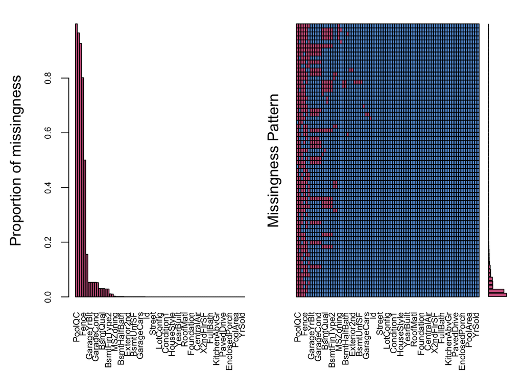

```
##
##  Variables sorted by number of missings:
##       Variable       Count
##         PoolQC 0.997943797
##    MiscFeature 0.965044551
##          Alley 0.926662097
##          Fence 0.801233722
##    FireplaceQu 0.500342700
##    LotFrontage 0.155586018
##    GarageYrBlt 0.053461275
##   GarageFinish 0.053461275
##     GarageQual 0.053461275
##     GarageCond 0.053461275
##     GarageType 0.052090473
##       BsmtCond 0.030843043
##       BsmtQual 0.030157642
##   BsmtExposure 0.030157642
##   BsmtFinType1 0.028786840
##   BsmtFinType2 0.028786840
##     MasVnrType 0.010966415
##     MasVnrArea 0.010281014
##       MSZoning 0.002741604
##      Utilities 0.001370802
##   BsmtFullBath 0.001370802
##   BsmtHalfBath 0.001370802
##     Functional 0.001370802
##    Exterior1st 0.000685401
##    Exterior2nd 0.000685401
##     BsmtFinSF1 0.000685401
##     BsmtFinSF2 0.000685401
##      BsmtUnfSF 0.000685401
##    TotalBsmtSF 0.000685401
##    KitchenQual 0.000685401
##     GarageCars 0.000685401
##     GarageArea 0.000685401
##       SaleType 0.000685401
##             Id 0.000000000
##     MSSubClass 0.000000000
##        LotArea 0.000000000
##         Street 0.000000000
```

[output cut: 28 more lines]

```
##   BedroomAbvGr 0.000000000
##   KitchenAbvGr 0.000000000
##   TotRmsAbvGrd 0.000000000
##     Fireplaces 0.000000000
##     PavedDrive 0.000000000
##     WoodDeckSF 0.000000000
##    OpenPorchSF 0.000000000
##  EnclosedPorch 0.000000000
##     X3SsnPorch 0.000000000
##    ScreenPorch 0.000000000
##       PoolArea 0.000000000
##        MiscVal 0.000000000
##         MoSold 0.000000000
##         YrSold 0.000000000
##  SaleCondition 0.000000000
```

Similar picture as for our training dataset however, we see small differences here. For example, the feature “LotFrontage” has a significant number of NA’s in the test dataset hence, we chose to clean this variable manually too.

```r
#take care of critical columns manually, rest using mice

dft$Alley = factor(dft$Alley, levels=c(levels(dft$Alley), "None")) #appending another level "None" to exisiting levels
dft$Alley[is.na(dft$Alley)] = "None" #replace NA's by "None"

# Fence : NA means "no fence"
dft$Fence = factor(dft$Fence, levels=c(levels(dft$Fence), "No"))
dft$Fence[is.na(dft$Fence)] = "No"

# FireplaceQu : NA means "no fireplace"
dft$FireplaceQu = factor(dft$FireplaceQu, levels=c(levels(dft$FireplaceQu), "No"))
dft$FireplaceQu[is.na(dft$FireplaceQu)] = "No"

# MiscFeature : NA = "no misc feature"
dft$MiscFeature = factor(dft$MiscFeature, levels=c(levels(dft$MiscFeature), "No"))
dft$MiscFeature[is.na(dft$MiscFeature)] = "No"

# PoolQC : data description says NA means "no pool"
dft$PoolQC = factor(dft$PoolQC, levels=c(levels(dft$PoolQC), "No"))
dft$PoolQC[is.na(dft$PoolQC)] = "No"

# LotFrontage : NA most likely means no lot frontage
dft$LotFrontage[is.na(dft$LotFrontage)] <- 0

#Factorize features. Some numerical features are actually categories
dft$MSSubClass <- as.factor(dft$MSSubClass)
dft$MoSold <- as.factor(dft$MoSold)
```

## Data Imputation Test Dataset

```r
impt = mice(dft, pred=quickpred(dft, minpuc = 0.25, exclude = c("PoolQC", "MiscFeature", "Alley", "Fence", "FireplaceQu", "LotFrontage", "SalePrice")), maxit = 1, method = 'cart')
summary(impt)
completedDataTest <- complete(impt,1)
```

Doublechecking the “cleaniliness” of our data.

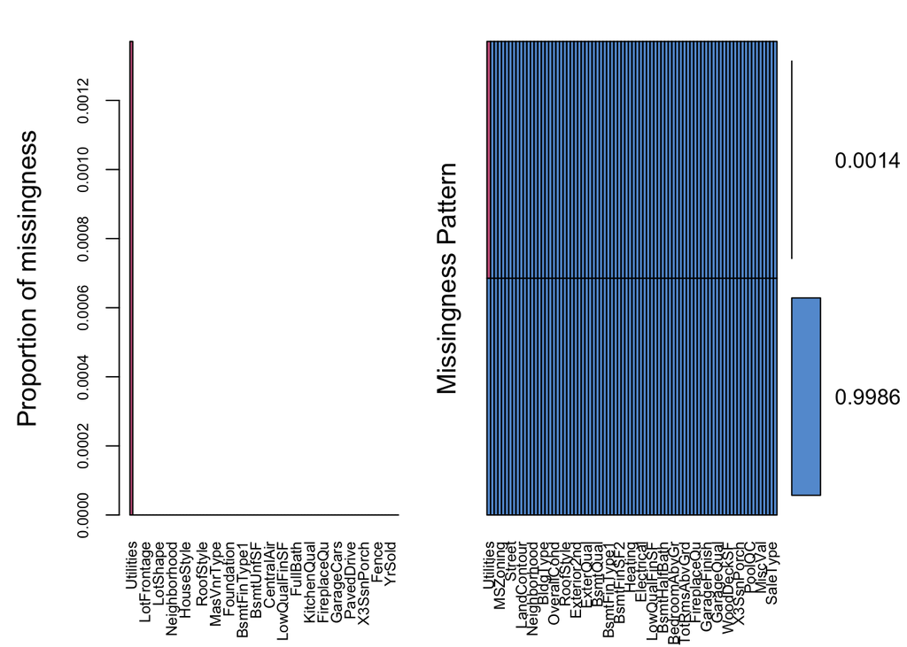

```
##
##  Variables sorted by number of missings:
##       Variable       Count
##      Utilities 0.001370802
##             Id 0.000000000
##     MSSubClass 0.000000000
##       MSZoning 0.000000000
##    LotFrontage 0.000000000
##        LotArea 0.000000000
##         Street 0.000000000
##          Alley 0.000000000
##       LotShape 0.000000000
##    LandContour 0.000000000
##      LotConfig 0.000000000
##      LandSlope 0.000000000
##   Neighborhood 0.000000000
##     Condition1 0.000000000
##     Condition2 0.000000000
##       BldgType 0.000000000
##     HouseStyle 0.000000000
##    OverallQual 0.000000000
##    OverallCond 0.000000000
##      YearBuilt 0.000000000
##   YearRemodAdd 0.000000000
##      RoofStyle 0.000000000
##       RoofMatl 0.000000000
##    Exterior1st 0.000000000
##    Exterior2nd 0.000000000
##     MasVnrType 0.000000000
##     MasVnrArea 0.000000000
##      ExterQual 0.000000000
##      ExterCond 0.000000000
##     Foundation 0.000000000
##       BsmtQual 0.000000000
##       BsmtCond 0.000000000
##   BsmtExposure 0.000000000
##   BsmtFinType1 0.000000000
##     BsmtFinSF1 0.000000000
##   BsmtFinType2 0.000000000
##     BsmtFinSF2 0.000000000
```

[output cut: 28 more lines]

```
##     PavedDrive 0.000000000
##     WoodDeckSF 0.000000000
##    OpenPorchSF 0.000000000
##  EnclosedPorch 0.000000000
##     X3SsnPorch 0.000000000
##    ScreenPorch 0.000000000
##       PoolArea 0.000000000
##         PoolQC 0.000000000
##          Fence 0.000000000
##    MiscFeature 0.000000000
##        MiscVal 0.000000000
##         MoSold 0.000000000
##         YrSold 0.000000000
##       SaleType 0.000000000
##  SaleCondition 0.000000000
```

```r
#An intermediate plot will show that utilities still contains NA's hence, we will remove them manually
df_aggr = aggr(completedDataTest, col=mdc(1:2), numbers=TRUE, sortVars=TRUE, labels=names(completedDataTest), cex.axis=.7, gap=3, ylab=c("Proportion of missingness","Missingness Pattern"))
```

This diagnostic plot illustrates that still there is one variable which causes NA’s. We will check it manually and find out that it only has one value. As this feature contains almost no information, we will remove it. Other than that, our datasets seem pretty clean and we’re good to jump onto the more interesting parts of feature engineering and modelling!

```r
# Remove the Utilities feature from the dataset (It only has one value)
completedData <- completedData[,-which(names(completedData) == "Utilities")]
completedDataTest <- completedDataTest[,-which(names(completedDataTest) == "Utilities")]
```

## Skewness

Before running a linear model we need to observe how our target variable behaves. Hence we will plot the data points of *SalePrice* in order to check skewness.

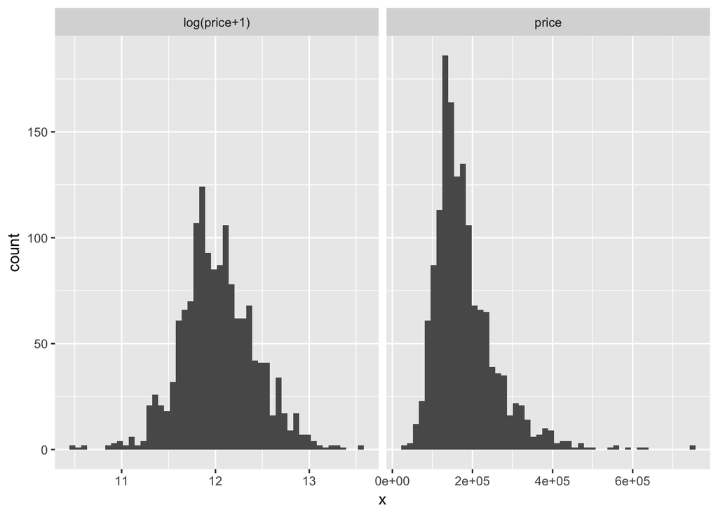

```r
#Get data frame of SalePrice and log(SalePrice + 1) for plotting
dfl <- rbind(data.frame(version="log(price+1)",x=log(completedData$SalePrice + 1)), data.frame(version="price",x=completedData$SalePrice))

ggplot(data=dfl) +
  facet_wrap(~version,ncol=2,scales="free_x") +
  geom_histogram(aes(x=x), bins = 50)
```

Our intuition proved right and indeed we could observe skewness in the target variable. In order to counteract this and obtain a behavior that follows more a normal distribution we will transform the target value by applying the natural log to our response variable *SalePrice*.

```r
# Log transform the target for official scoring
completedData$SalePrice <- log1p(completedData$SalePrice)
```

The same “skewness” observed in the target variable also affects other variables. To facilitate the application of the regression model we are going to also eliminate this skewness. For numeric feature with excessive skewness, perform log transformation.

```r
column_types <- sapply(names(completedData),function(x){class(completedData[[x]])})
numeric_columns <-names(column_types[column_types != "factor"])

# skew of each variable
skew <- sapply(numeric_columns,function(x){skewness(completedData[[x]],na.rm = T)})
# transform all variables above a threshold skewness.

#Testing different thresholds might lead to improved results
skew <- skew[skew > 0.75]
for(x in names(skew)) {
  completedData[[x]] <- log(completedData[[x]] + 1)
}
```

Performing the same for the test data.

```r
column_types <- sapply(names(completedDataTest),function(x){class(completedDataTest[[x]])})
numeric_columns <-names(column_types[column_types != "factor"])

skew <- sapply(numeric_columns,function(x){skewness(completedDataTest[[x]],na.rm = T)})
skew <- skew[skew > 0.75]
for(x in names(skew)) {
  completedDataTest[[x]] <- log(completedDataTest[[x]] + 1)
}
```

## Removing Outliers

```r
remove_outliers <- function(x, na.rm = TRUE, ...) {
  qnt <- quantile(x, probs=c(.25, .75), na.rm = na.rm, ...)
  H <- 1.5 * IQR(x, na.rm = na.rm)
  y <- x
  y
}

feature_classes <- sapply(names(completedData),function(x){class(completedData[[x]])})

num_feats <-names(feature_classes[feature_classes != "factor"])
categorical <- names(feature_classes[feature_classes == "factor"])

num_df <- completedData[num_feats]
categorical_df <- completedData[categorical]

completedData1 <- sapply(names(num_df),function(x){remove_outliers(num_df[[x]])})

completedData <- cbind(completedData1, categorical_df)
```

# Feature Engineering

Oftentimes information is hidden within the data such as some particularly valuable insight is hidden between the lines of a good book. To extract such hidden information we will perform feature engineering and create new possible predictors which could help us to build a better model. For some specific new features, we chose to add descriptions to illustrate the logic behind combining and extracting information.

**Refurb** *If Year Built is different from Year Remodeled then we can assume there was some refurbishment, the refurbishment will likely increase the property value*

```r
#for train set
completedData = completedData %>%
  mutate(Refurb = ifelse(YearBuilt != YearRemodAdd, 1, 0))

#for test set
completedDataTest = completedDataTest %>%
  mutate(Refurb = ifelse(YearBuilt != YearRemodAdd, 1, 0))
```

**Seasonality** *Seasonality (binary): We can assume cyclical events where the month and year sold had an effect on the house price. For instance, in low-interest rate cycles (e.g 2015-2017) the prices of houses are higher than in low-interest periods. Since this particular dataset focusses on the years 2006-2010 we need to do some research and assign categories according to the pricing development during this time. Such events are also called unsystematic since they are influenced by external market forces and push prices out of their market equilibrium.*

```r
#check levels of month & year sold
levels(df$MoSold) # 1 - 12 indicating Jan - Dec
```

```
##  [1] "1"  "2"  "3"  "4"  "5"  "6"  "7"  "8"  "9"  "10" "11" "12"
```

```r
levels(df$YrSold) #2006 - 2010
```

```r
#for train set
completedData = completedData %>%
  mutate(Season = ifelse(YrSold  == 2006 & MoSold != c(1, 2, 11, 12), "A",
                         ifelse(YrSold  == 2006 & MoSold == c(1, 2, 11, 12),"B",
                         ifelse(YrSold  != c(2008, 2009) & MoSold != c(1, 2, 11, 12),"C",
                         ifelse(YrSold  == c(2008, 2009),"F", "D")))))

completedData$Season = as.factor(completedData$Season)


#for test set
completedDataTest = completedDataTest %>%
  mutate(Season = ifelse(YrSold  == 2006 & MoSold != c(1, 2, 11, 12), "A",
                         ifelse(YrSold  == 2006 & MoSold == c(1, 2, 11, 12),"B",
                         ifelse(YrSold  != c(2008, 2009) & MoSold != c(1, 2, 11, 12),"C",
                         ifelse(YrSold  == c(2008, 2009),"F", "D")))))

completedDataTest$Season = as.factor(completedDataTest$Season)
```

*Additional Features*

```r
#total floor area
completedData$FlrSF <- sum(completedData$X1stFlrSF, completedData$X2ndFlrSF)

#total number of full bathrooms
completedData$TotFullBath <- sum(completedData$BsmtFullBath, completedData$FullBath)

#total number of half bathrooms
completedData$TotSmallBath <- sum(completedData$BsmtHalfBath, completedData$HalfBath)

#recoding values
levels(completedData$CentralAir) <- c(0,1)
completedData$CentralAir <- as.numeric(as.character(completedData$CentralAir))
#converting to numeric
completedData$BsmntUnf <- completedData$BsmtUnfSF/completedData$TotalBsmtSF

#Unfinished basement area
completedData$BsmntUnf[is.na(completedData$BsmntUnf)] <- 0

#Unfinished house area
completedData$AreaUnf <- completedData$LowQualFinSF/completedData$X1stFlrSF+completedData$X2ndFlrSF

#Garage and house built at the same time
completedData$TotBuild <- completedData$GarageYrBlt-completedData$YearBuilt

#Total Completed House Area
completedData$TotArea <- sum(completedData$BsmtFinSF1, completedData$BsmtFinSF2, completedData$LotArea, completedData$TotalBsmtSF, completedData$GrLivArea)

#Age of the house when sold
completedData$Age <- completedData$YrSold-completedData$YearBuilt

#Years since remodeling until the house was sold
completedData$RemodSold <- completedData$YrSold-completedData$YearRemod

##Drop Id
completedData <- completedData[-1]
```

*Additional Features Test Set*

```r
#total floor area
completedDataTest$FlrSF <- sum(completedDataTest$X1stFlrSF, completedDataTest$X2ndFlrSF)

#total number of full bathrooms
completedDataTest$TotFullBath <- sum(completedDataTest$BsmtFullBath, completedDataTest$FullBath)

#total number of half bathrooms
completedDataTest$TotSmallBath <- sum(completedDataTest$BsmtHalfBath, completedDataTest$HalfBath)

#recoding values
levels(completedDataTest$CentralAir) <- c(0,1)
completedDataTest$CentralAir <- as.numeric(as.character(completedDataTest$CentralAir))
#converting to numeric
completedDataTest$BsmntUnf <- completedDataTest$BsmtUnfSF/completedDataTest$TotalBsmtSF

#Unfinished basement area
completedDataTest$BsmntUnf[is.na(completedDataTest$BsmntUnf)] <- 0

#Unfinished house area
completedDataTest$AreaUnf <- completedDataTest$LowQualFinSF/completedDataTest$X1stFlrSF+completedDataTest$X2ndFlrSF

#Garage and house built at the same time
completedDataTest$TotBuild <- completedDataTest$GarageYrBlt-completedDataTest$YearBuilt

#Total Completed House Area
completedDataTest$TotArea <- sum(completedDataTest$BsmtFinSF1, completedDataTest$BsmtFinSF2, completedDataTest$LotArea, completedDataTest$TotalBsmtSF, completedDataTest$GrLivArea)

#Age of the house when sold
completedDataTest$Age <- completedDataTest$YrSold-completedDataTest$YearBuilt

#Years since remodeling until the house was sold
completedDataTest$RemodSold <- completedDataTest$YrSold-completedDataTest$YearRemod

##Drop Id
completedDataTest <- completedDataTest[-1]
```

# Feature Selection

## Direct Techniques

### Forward Stepwise Selection

Forward Stepwise Selection is often used to generate an initial screening of the candidate variables when a large pool of variables exists. As this is the case for our housing dataset such selection procedure makes sense. One reasonable method would is to deploy such forward selection procedure to obtain the best ten to fifteen variables and then apply the all-possible algorithm to the variables within this subset. *This process takes time to run - get yourself another beer!*

```r
#Get olsrr package if not already installed
library(olsrr)
```

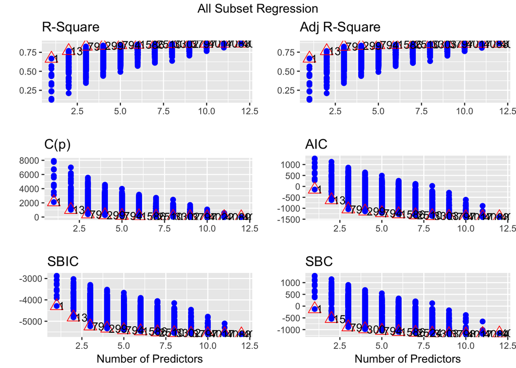

```r
model <- lm(SalePrice ~ Fireplaces + Neighborhood + OverallQual + GrLivArea + Age +  KitchenQual + ExterQual + BsmtQual + TotalBsmtSF + YearRemodAdd + CentralAir + HeatingQC, data = completedData)
K = ols_all_subset(model)
plot(K)
```

Now we will check for the best subsets of features as well as the importance of the features.

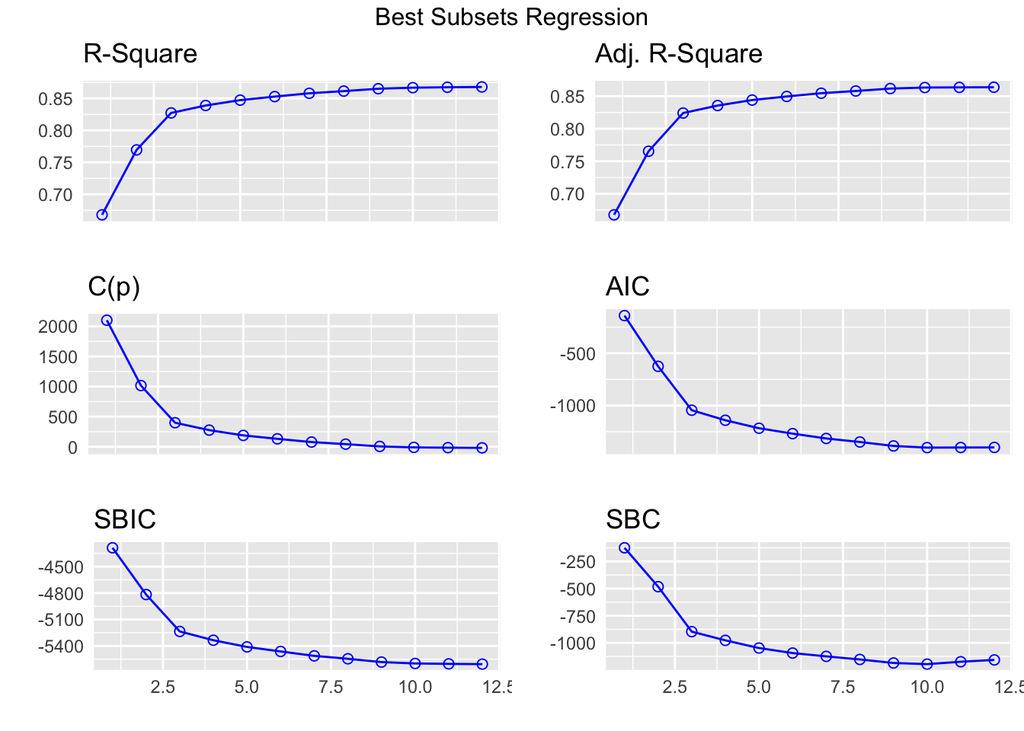

```r
B = ols_best_subset(model)
plot(B)
```

## Indirect Techniques

### Recursive Feature Selection - Wrappers

Wrapper methods use a selection of sets of features related to a specific search problem where different combinations are prepared, evaluated and compared to other combinations. We will use recursive feature selection as part of our feature selection process.

```r
size_sets = seq(1,length(completedData)-1, 5)
control <- rfeControl(functions = rfFuncs, method='cv', number=5)
results <- rfe(completedData[names(completedData) != 'SalePrice'], completedData$SalePrice, sizes = size_sets, rfeControl = control)
print(results)
```

```
##
## Recursive feature selection
##
## Outer resampling method: Cross-Validated (5 fold)
##
## Resampling performance over subset size:
##
##  Variables   RMSE Rsquared     MAE   RMSESD RsquaredSD     MAESD Selected
##          1 0.3064   0.4349 0.23375 0.013705    0.04681 0.0099924
##          6 0.1561   0.8505 0.10928 0.008942    0.01732 0.0025368
##         11 0.1472   0.8694 0.09989 0.006620    0.01671 0.0015698
##         16 0.1394   0.8833 0.09382 0.007963    0.01988 0.0025571
##         21 0.1376   0.8877 0.09211 0.007445    0.01527 0.0015749        *
##         26 0.1388   0.8866 0.09222 0.007827    0.01511 0.0017872
##         31 0.1400   0.8849 0.09297 0.006545    0.01546 0.0017157
##         36 0.1406   0.8841 0.09350 0.005396    0.01410 0.0014983
##         41 0.1407   0.8844 0.09312 0.006297    0.01351 0.0017955
##         46 0.1393   0.8868 0.09212 0.005847    0.01307 0.0016028
##         51 0.1399   0.8860 0.09254 0.005909    0.01333 0.0013514
##         56 0.1402   0.8856 0.09270 0.006260    0.01477 0.0017246
##         61 0.1402   0.8860 0.09287 0.005317    0.01337 0.0017525
##         66 0.1412   0.8849 0.09312 0.005159    0.01425 0.0009707
##         71 0.1411   0.8858 0.09325 0.005388    0.01403 0.0010304
##         76 0.1417   0.8848 0.09395 0.005804    0.01448 0.0014636
##         81 0.1418   0.8847 0.09379 0.005432    0.01471 0.0013833
##         86 0.1416   0.8853 0.09407 0.005844    0.01432 0.0016765
##         89 0.1418   0.8857 0.09389 0.006742    0.01473 0.0017215
##
## The top 5 variables (out of 21):
##    GrLivArea, Neighborhood, OverallQual, TotalBsmtSF, MSSubClass
```

```r
predictors(results)
```

```
##  [1] "GrLivArea"    "Neighborhood" "OverallQual"  "TotalBsmtSF"
##  [5] "MSSubClass"   "X1stFlrSF"    "BsmtFinSF1"   "GarageArea"
##  [9] "LotArea"      "X2ndFlrSF"    "GarageCars"   "OverallCond"
## [13] "AreaUnf"      "FireplaceQu"  "ExterQual"    "YearRemodAdd"
## [17] "RemodSold"    "Age"          "BsmntUnf"     "KitchenQual"
## [21] "GarageType"
```

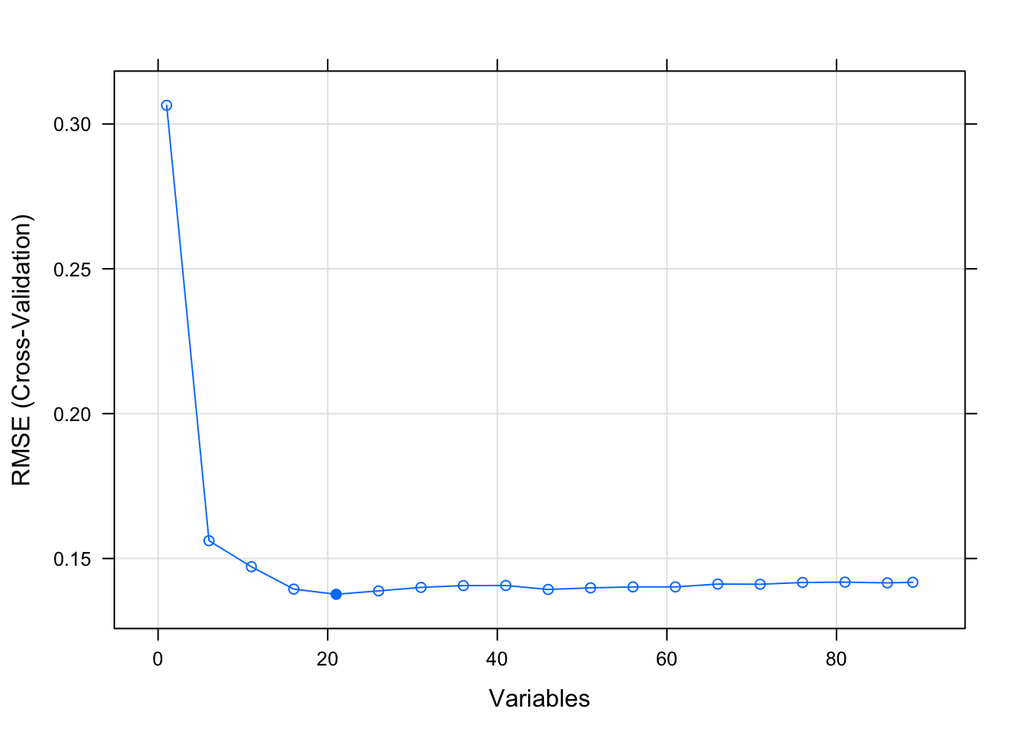

```r
p1 = plot(results, type=c('g','o'))
p1
```

The output reveals that almost 90% of the information contained in the target variable *SalePrice* can be explained by using only 16 variables. We obtain an $R^2$ of 88% for the following predictors:

Great, let’s keep this result for the record when performing our actual modeling.

## Tree Based Methods

To determine which features we want to keep and which will just add noise to our predictive model we will now grow trees. A Japanese Forest full of Bonsai. Well, not literally but we will - similar to a Bonsai - prune the tree at some point in order to make it prettier. In data science terms this means reducing our model’s RMSE reflecting a higher technical quality of selected features. In a secondary step, we will use *Boosting* for the same purpose of selecting variables containing information that will make our model more accurate. For this, we will use our pre-processed training dataset.

### Random Forest

```r
set.seed (1)
train = sample(1:nrow(completedData), nrow(completedData)/2)
tree.house=tree(SalePrice~ .,completedData ,subset=train)
summary(tree.house)
```

```
##
## Regression tree:
## tree(formula = SalePrice ~ ., data = completedData, subset = train)
## Variables actually used in tree construction:
## [1] "OverallQual"  "Neighborhood" "GrLivArea"    "LotArea"
## [5] "TotalBsmtSF"
## Number of terminal nodes:  12
## Residual mean deviance:  0.03507 = 25.18 / 718
## Distribution of residuals:
##      Min.   1st Qu.    Median      Mean   3rd Qu.      Max.
## -1.053000 -0.103000  0.003617  0.000000  0.113200  0.589000
```

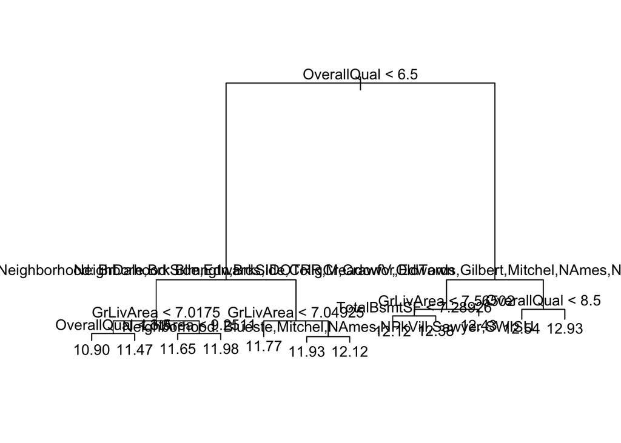

```r
#Fitting the random forest
plot(tree.house)
text(tree.house ,pretty=0)
```

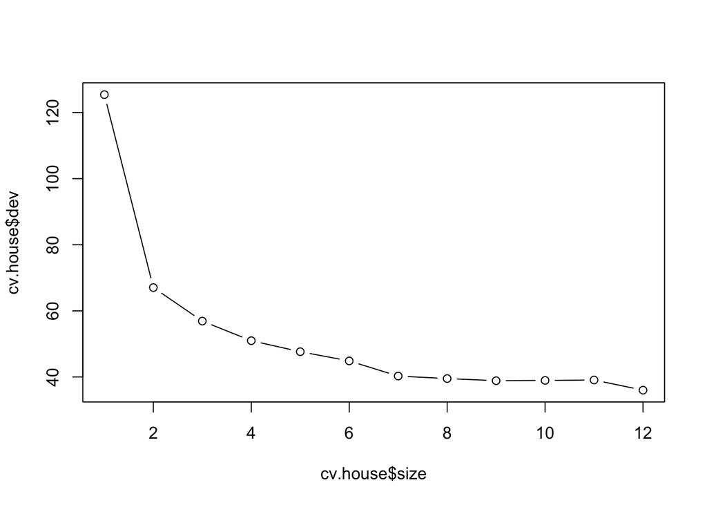

```r
#Check where to prune the tree
cv.house=cv.tree(tree.house)
plot(cv.house$size ,cv.house$dev ,type='b')
```

The plot indicates that there is a marginal gain in reducing the model error by pruning the tree between 6 and 9. Consequently, we will play around with those values and observe how many levels yield the best result. Having tested all values between 6 and 9 the best result has proved to be 7 nodes.

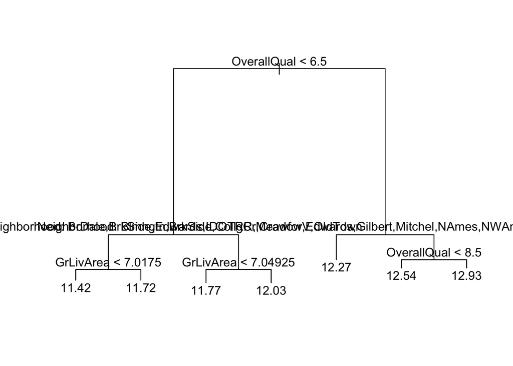

```r
prune.house=prune.tree(tree.house ,best=7)
plot(prune.house)
text(prune.house ,pretty=0)
```

```r
summary(prune.house)
```

```
##
## Regression tree:
## snip.tree(tree = tree.house, nodes = c(11L, 9L, 6L, 8L))
## Variables actually used in tree construction:
## [1] "OverallQual"  "Neighborhood" "GrLivArea"
## Number of terminal nodes:  7
## Residual mean deviance:  0.04762 = 34.43 / 723
## Distribution of residuals:
##      Min.   1st Qu.    Median      Mean   3rd Qu.      Max.
## -1.126000 -0.123600  0.005088  0.000000  0.121200  0.692500
```

Based on our beautiful tree, here are the features according to their importance:

- OverallQual:
- Overall material and finish quality
- Neighborhood:
- Physical locations within Ames city limits
- GrLivArea:
- Above grade (ground) living area square feet

### Crossvalidation

To cross-validate, we will use the test dataset and observe the MSE.

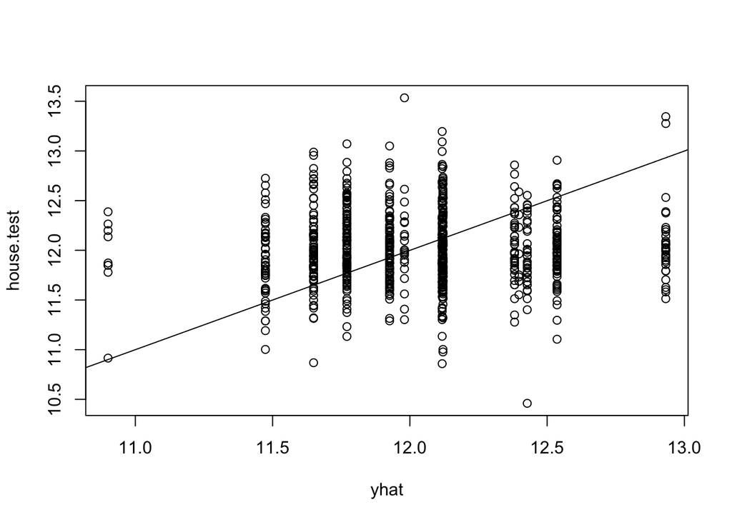

```r
yhat=predict(tree.house ,newdata=completedDataTest[-train ,])
house.test=completedData[-train,c("SalePrice")]
plot(yhat,house.test)
abline(0,1)
```

```r
mean((yhat-house.test)^2)
```

```
## [1] 0.2784064
```

### Boosting

This section has been inspired by the book “Introduction to Statistical Learning” by Robert Tibshirani and Trevor Hastie and this Rbloggers [post]https://www.r-bloggers.com/gradient-boosting-in-r/.

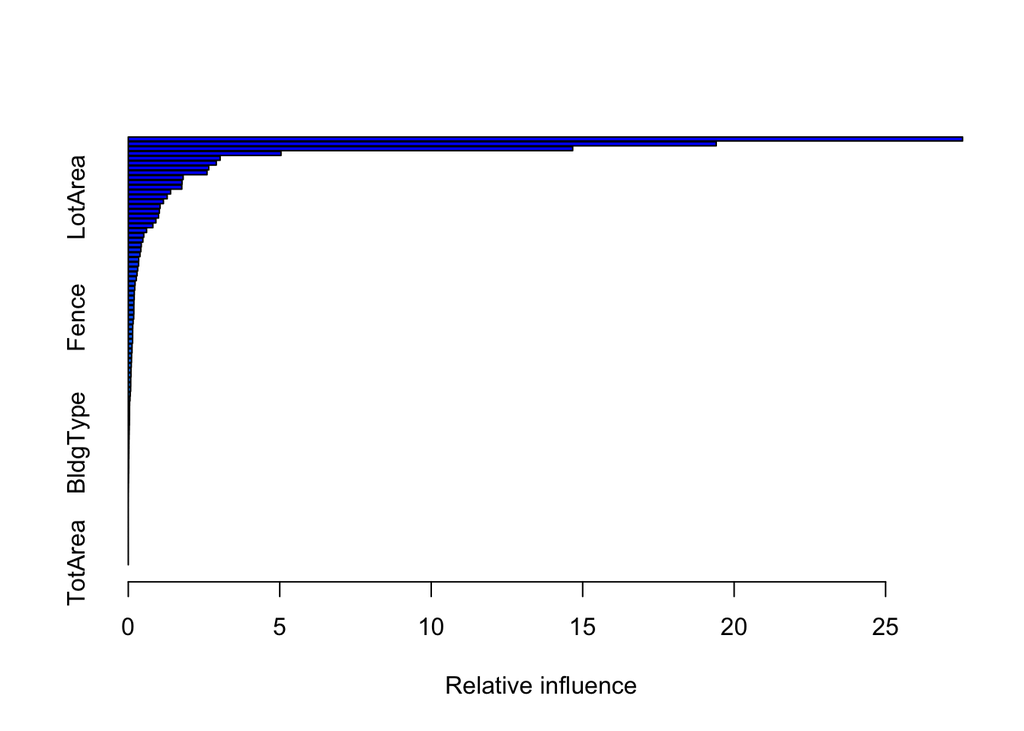

```
##                         var      rel.inf
## OverallQual     OverallQual 2.754091e+01
## Neighborhood   Neighborhood 1.940837e+01
## GrLivArea         GrLivArea 1.467000e+01
## TotalBsmtSF     TotalBsmtSF 5.041187e+00
## X1stFlrSF         X1stFlrSF 3.031621e+00
## MSSubClass       MSSubClass 2.904334e+00
## BsmtFinSF1       BsmtFinSF1 2.654997e+00
## GarageArea       GarageArea 2.598825e+00
## MoSold               MoSold 1.810582e+00
## CentralAir       CentralAir 1.773569e+00
## GarageCars       GarageCars 1.766266e+00
## OverallCond     OverallCond 1.396117e+00
## LotArea             LotArea 1.283453e+00
## RemodSold         RemodSold 1.159437e+00
## KitchenQual     KitchenQual 1.049412e+00
## SaleCondition SaleCondition 1.024865e+00
## Exterior2nd     Exterior2nd 9.985789e-01
## FireplaceQu     FireplaceQu 9.106277e-01
## YearRemodAdd   YearRemodAdd 8.104418e-01
## GarageFinish   GarageFinish 6.037283e-01
## Exterior1st     Exterior1st 5.108838e-01
## GarageType       GarageType 4.811666e-01
## ExterCond         ExterCond 4.291282e-01
## WoodDeckSF       WoodDeckSF 4.135685e-01
## ExterQual         ExterQual 3.866363e-01
## BsmtUnfSF         BsmtUnfSF 3.430925e-01
## BsmtQual           BsmtQual 3.381845e-01
## BsmtFinType1   BsmtFinType1 3.097725e-01
## YearBuilt         YearBuilt 2.882310e-01
## TotRmsAbvGrd   TotRmsAbvGrd 2.640392e-01
## MSZoning           MSZoning 2.239960e-01
## EnclosedPorch EnclosedPorch 2.124855e-01
## Age                     Age 1.978189e-01
## SaleType           SaleType 1.949915e-01
## Functional       Functional 1.853773e-01
## GarageCond       GarageCond 1.830882e-01
## GarageYrBlt     GarageYrBlt 1.829911e-01
## Fence                 Fence 1.786754e-01
## BsmtExposure   BsmtExposure 1.598497e-01
```

[output cut: 35 more lines]

```
## MiscFeature     MiscFeature 1.057003e-03
## LandSlope         LandSlope 7.007926e-04
## AreaUnf             AreaUnf 1.287259e-04
## LowQualFinSF   LowQualFinSF 0.000000e+00
## X3SsnPorch       X3SsnPorch 0.000000e+00
## PoolArea           PoolArea 0.000000e+00
## Street               Street 0.000000e+00
## Condition2       Condition2 0.000000e+00
## RoofMatl           RoofMatl 0.000000e+00
## Heating             Heating 0.000000e+00
## PoolQC               PoolQC 0.000000e+00
## FlrSF                 FlrSF 0.000000e+00
## TotFullBath     TotFullBath 0.000000e+00
## TotSmallBath   TotSmallBath 0.000000e+00
## TotArea             TotArea 0.000000e+00
```

```r
set.seed (1)
boost.house=gbm(SalePrice ~.,data=completedData[train,],distribution ="gaussian",n.trees=5000, interaction.depth=4, shrinkage = 0.01)
#call summary
summary(boost.house)
```

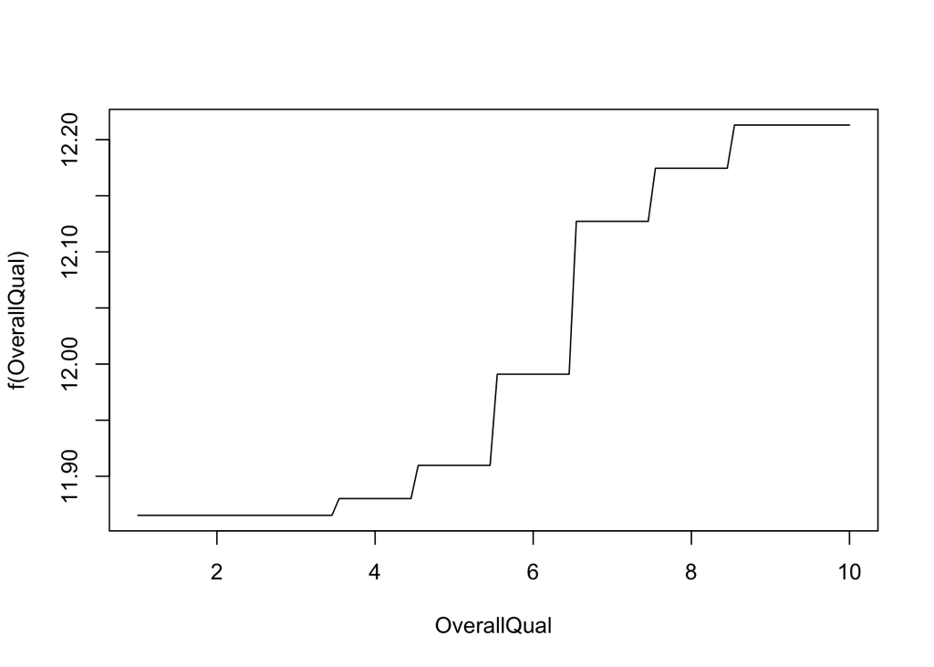

```r
#Plot of Response variable with OverallQual variable
plot(boost.house,i="OverallQual")
```

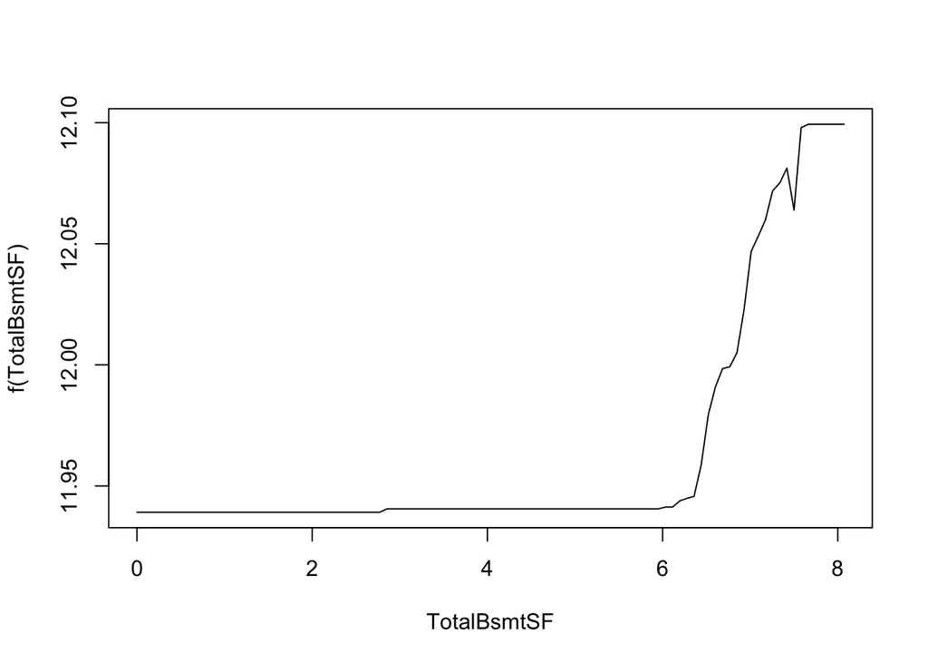

```r
#Inverse relation with OverallQual  variable

plot(boost.house,i="TotalBsmtSF")
```

```r
#as the average number of rooms increases the the price increases
```

The above plot shows the relation between the variables in the x-axis and the mapping function $f(x)$ on the y-axis. The first plot shows that OverallQual, as well as TotalBsmtSF, are positively correlated with the response variable SalePrice.

```r
n.trees = seq(from=100 ,to=10000, by=100) #no of trees-a vector of 100 values

#Generating a Prediction matrix for each Tree
predmatrix<-predict(boost.house,completedData[-train,],n.trees = n.trees)
dim(predmatrix) #dimensions of the Prediction Matrix
```

```
## [1] 730 100
```

```r
#Calculating The Mean squared Test Error
test.error<-with(completedData[-train,],apply( (predmatrix-SalePrice)^2,2,mean))
head(test.error) #contains the Mean squared test error for each of the 100 trees averaged
```

```
##        100        200        300        400        500        600
## 0.05059529 0.02812009 0.02152880 0.01946020 0.01867059 0.01840175
```

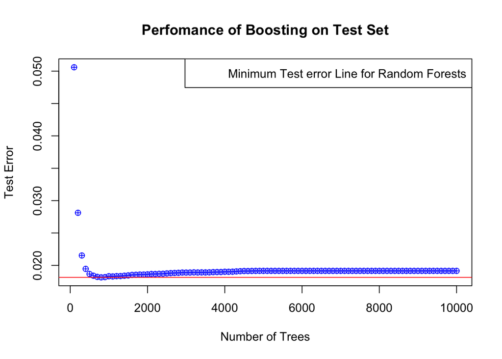

```r
#Plotting the test error vs number of trees
plot(n.trees , test.error , pch=10,col="blue",xlab="Number of Trees",ylab="Test Error", main = "Perfomance of Boosting on Test Set")

#Adding the RandomForests Minimum Error line trained on same data and similar parameters
abline(h = min(test.error),col="red")

#Test.err is the test error of a Random forest fitted on same data
legend("topright",c("Minimum Test error Line for Random Forests"),col="red",lty=0.5,lwd=0.5)
```

```r
n.trees = seq(from=400 ,to=1000, by=50) #no of trees-a vector of 100 values

#Generating a Prediction matrix for each Tree
predmatrix<-predict(boost.house,completedData[-train,],n.trees = n.trees)
dim(predmatrix) #dimensions of the Prediction Matrix
```

```
## [1] 730  13
```

```r
#Calculating The Mean squared Test Error
test.error<-with(completedData[-train,],apply( (predmatrix-SalePrice)^2,2,mean))
head(test.error) #contains the Mean squared test error for each of the 100 trees averaged
```

```
##        400        450        500        550        600        650
## 0.01946020 0.01894820 0.01867059 0.01849630 0.01840175 0.01826467
```

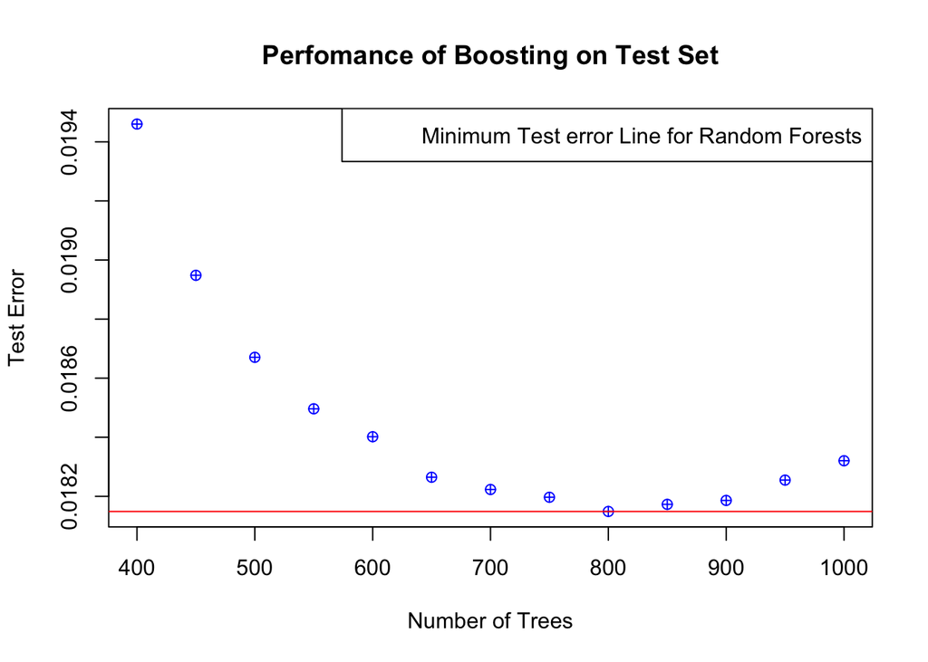

```r
#Plotting the test error vs number of trees
plot(n.trees , test.error , pch=10,col="blue",xlab="Number of Trees",ylab="Test Error", main = "Perfomance of Boosting on Test Set")

#adding the RandomForests Minimum Error line trained on same data and similar parameters
abline(h = min(test.error),col="red")

#test.err is the test error of a Random forest fitted on same data
legend("topright",c("Minimum Test error Line for Random Forests"),col="red",lty=0.5,lwd=0.5)
```

```r
dim(predmatrix)
```

```
## [1] 730  13
```

```r
head(test.error)
```

```
##        400        450        500        550        600        650
## 0.01946020 0.01894820 0.01867059 0.01849630 0.01840175 0.01826467
```

# Modeling

Wow, a lot of interesting steps we did until now but one might ask - what for? If you remember, our initial aim was to predict the SalePrice of houses in Ames, Iowa. For this, we first cleaned, transformed and enriched the data through feature engineering. In a second step, we used feature selection methods that would provide us with the information content of our explanatory variables. With all this new (and pretty awesome) info, we will now proceed to embed our knowledge into an actual predictive model. Hence, we will first split out dataset into training, test and validation. This is useful in order to ensure a general yet, explanatory model that avoids bias.

So put your seatbelts on and let’s get some predictions!

## Test Training Split

```r
splitdf <- function(dataframe, seed=NULL) {
  if (!is.null(seed)) set.seed(seed)
    index <- 1:nrow(dataframe)
    trainindex <- sample(index, trunc(length(index)/1.5))
    trainset <- dataframe[trainindex, ]
    testset <- dataframe[-trainindex, ]
    list(trainset=trainset,testset=testset)
}

splits <- splitdf(completedData, seed=1)
training <- splits$trainset
validation <- splits$testset

set.seed(121)
train_control_config <- trainControl(method = "repeatedcv",
                       number = 5,
                       repeats = 1,
                       returnResamp = "all")
```

## Linear Regression Model

```r
m1 <- glm(formula=SalePrice ~ OverallQual + (OverallQual)^2 + Age + Neighborhood + GrLivArea + (GrLivArea)^2 + TotalBsmtSF + X1stFlrSF + BsmtFinSF1 + GarageArea + MoSold + CentralAir + GarageCars + OverallCond + RemodSold + LotArea + Exterior2nd + SaleCondition + GrLivArea:LotArea + Refurb:Age +  OverallCond:Age, family=gaussian, data=training)


for (x in names(validation)) {
  m1$xlevels[[x]] = union(m1$xlevels[[x]],
    levels(validation[[x]]))
}

#SANITY CHECKS IF THE CODE IS SAFE
m1.pred = predict(m1, validation)
m1.pred[is.na(m1.pred)] = 0


my_data=as.data.frame(cbind(predicted=m1.pred,observed=validation$SalePrice))

paste("Full Linear Regression RMSE = ", sqrt(mean((m1.pred - validation$SalePrice)^2)))
```

```
## [1] "Full Linear Regression RMSE =  0.146964215768477"
```

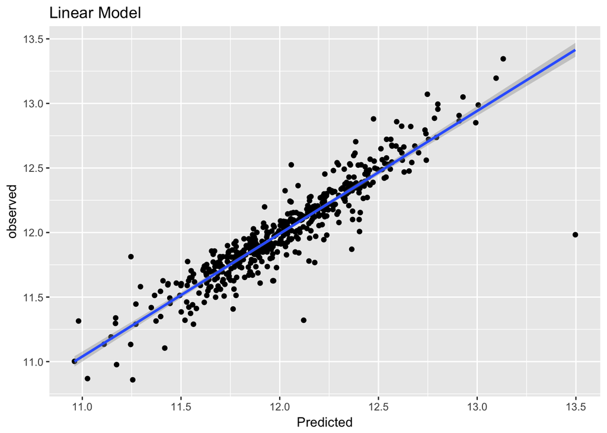

```r
m1.pred <- predict(m1, completedDataTest)

sol <- data.frame(Id=dft$Id, SalePrice=exp(m1.pred))
write.csv(sol, file="solution.csv", row.names=F)

ggplot(my_data,aes(predicted,observed))+
  geom_point() + geom_smooth(method = "lm") +
  labs(x="Predicted") +
  ggtitle('Linear Model')
```

# Conclusion

If we were again to ask a home buyer to explain their dream house, they would probably not guess anymore but reach out to us and ask for a prediction of the house they want to buy based on certain information. So, in the end, what can we tell potential house buyers?

1. There is no ultimate model that will determine 100% accurately the price of a house.
2. Using only 16 variables we were able to explain almost 90% of the information contained in the SalePrice with an $R^2$ of 88%. Using all 90 variables would only marginally increase the information gain thus, we were able to create a good yet, simple model (p.s. Data Scientist love this!)
3. Our analysis yielded an RMSE of residual mean squared error of 13-14.5%, varying on the input data. RMSE can be interpreted as the standard deviation of the unexplained variance and has the useful property of being in the same units as the response variable. This is a fair result which can be used as a precursor of further qualitative analyses when determining the real value of a house.
4. Modeling is an iterative process that follows a strict structure with back- and forward testing. Using tree-based methods, alongside direct and indirect feature selection techniques we were able to come up with better results.
5. Feature engineering reveals patterns hidden in the data. We accomplished to build a good model using new features in their interaction such as Refurb:Age and OverallCond:Age.
6. Data cleaning is no fun but there are ways, such as plots, to identify critical variables and clean them manually and let pre-built packages take care of less critical variables. This saves time and is more efficient.

## Last Note

Don’t fear when buying a house! Gladly, there are data scientists like us to help you out! Not only by making the life of fraudulent real estate agents harder but also helping to bring more transparency to the housing market.

Thank you for reading our analysis and we hope you had more than just one beer to make it so far!

**Cheers!**